# Homework 07

Use either R or Python.

## Question 1: LDA

Let’s start by estimating the components of LDA. From the lecture notes, for each target point $\mathbf{x}_0$, we find the class label $k$ with the largest score

$$\mathbf{x}_0^{\mathsf T}\boldsymbol{\Sigma}^{-1}\boldsymbol{\mu}_k
-\frac12\boldsymbol{\mu}_k^{\mathsf T}\boldsymbol{\Sigma}^{-1}\boldsymbol{\mu}_k
+\log\pi_k.$$

Thus, we need to estimate:

- the prior probabilities $\pi_k$;
- the mean vector (centroid) $\boldsymbol{\mu}_k$ for each class; and
- the pooled covariance matrix $\boldsymbol{\Sigma}$.

Use saheart.csv, the `SAheart` data from `ElemStatLearn`. The two classes are defined by `chd`, the coronary heart disease indicator. Use all nine other variables as numerical predictors, coding `famhist` as 1 for `Absent` and 2 for `Present`. The following code constructs an $n\times9$ predictor matrix $\mathbf{X}$ and an $n$-entry response vector $\mathbf{y}$, where $n$ is the number of observations.

**R**

```r
heart <- read.csv("data/saheart.csv")
heart$famhist <- factor(heart$famhist, levels = c("Absent", "Present"))
X <- data.matrix(heart[, names(heart) != "chd"])
y <- heart$chd
```

**Python**

```python
import pandas as pd

heart = pd.read_csv("data/saheart.csv")
heart["famhist"] = heart["famhist"].map({"Absent": 1, "Present": 2})
X = heart.drop(columns="chd").to_numpy()
y = heart["chd"].to_numpy()
```

1. Calculate the prior probabilities, class means, and pooled covariance matrix from these data. Use the pooled covariance denominator $n-K$ from the lecture, where $K=2$ is the number of classes.
2. Use your estimated values to predict the label of each observation in the training data. These are in-sample fitted labels. Provide the confusion matrix, with observed classes in rows and predicted classes in columns. Check that the dimensions of your matrices and vectors match. Calculate the scores yourself for this part.
3. Perform the same LDA analysis using `MASS::lda` in R or `LinearDiscriminantAnalysis(solver="svd")` in Python, using the same numerical predictors and empirical class priors. Provide the confusion matrix. Do the results match?

## Solution to Question 1

Problem 1 asks us to estimate the quantities used by LDA from the `SAheart` data: the empirical class priors, the mean vector for each class, and one pooled covariance matrix. The code below uses the pooled covariance denominator $n-K$, as specified.

### (a)

```r
heart <- read.csv("data/saheart.csv")
heart$famhist <- factor(heart$famhist, levels = c("Absent", "Present"))
X <- data.matrix(heart[, names(heart) != "chd"])
y <- heart$chd

classes <- sort(unique(y))
K <- length(classes)
n <- nrow(X)
p <- ncol(X)

class_counts <- table(y)
priors <- as.numeric(class_counts) / n
names(priors) <- classes

class_means <- do.call(
  rbind,
  lapply(classes, function(k) colMeans(X[y == k, , drop = FALSE]))
)
rownames(class_means) <- classes

pooled_covariance <- matrix(0, nrow = p, ncol = p)
for (k in classes) {
  X_k <- X[y == k, , drop = FALSE]
  centered_k <- sweep(X_k, 2, class_means[as.character(k), ], "-")
  pooled_covariance <- pooled_covariance +
    crossprod(centered_k)
}
pooled_covariance <- pooled_covariance / (n - K)

priors
```

```
        0         1
0.6536797 0.3463203
```

```r
class_means
```

```
       sbp  tobacco      ldl adiposity  famhist    typea  obesity  alcohol
0 135.4603 2.634735 4.344238  23.96911 1.317881 52.36755 25.73745 15.93136
1 143.7375 5.524875 5.487938  28.12025 1.600000 54.49375 26.62294 19.14525
       age
0 38.85430
1 50.29375
```

```r
pooled_covariance
```

```
                  sbp    tobacco         ldl  adiposity    famhist        typea
sbp       405.4347786 14.5851882  4.58124834 49.1643582 0.33698819 -15.58772153
tobacco    14.5851882 19.2425564  0.76320271  7.5381093 0.01582050  -2.05730592
ldl         4.5812483  0.7632027  4.00058129  6.0326970 0.09185024   0.34459233
adiposity  49.1643582  7.5381093  6.03269701 56.7528931 0.43280832  -5.30956633
famhist     0.3369882  0.0158205  0.09185024  0.4328083 0.22583357   0.08112007
typea     -15.5877215 -2.0573059  0.34459233 -5.3095663 0.08112007  95.56564291
obesity    18.9388430  1.8334506  2.66005159 22.7078852 0.18402776   2.64006728
alcohol    64.4003517 20.5170451 -2.53290675 16.1190253 0.76846885   7.96003164
age        95.1338895 22.7654113  6.47892049 60.5086715 0.99736251 -20.27833492
             obesity     alcohol         age
sbp       18.9388430  64.4003517  95.1338895
tobacco    1.8334506  20.5170451  22.7654113
ldl        2.6600516  -2.5329068   6.4789205
adiposity 22.7078852  16.1190253  60.5086715
famhist    0.1840278   0.7684688   0.9973625
typea      2.6400673   7.9600316 -20.2783349
obesity   17.6154236   4.6893563  15.6969995
alcohol    4.6893563 598.2766133  27.8859413
age       15.6969995  27.8859413 184.1321373
```

### (b)

For the fitted labels, we calculate the LDA score for every observation and class, then assign each observation to the class with the largest score. The resulting table has observed classes in rows and predicted classes in columns.

```r
sigma_inverse <- solve(pooled_covariance)
mean_term <- rowSums((class_means %*% sigma_inverse) * class_means)

scores <- X %*% sigma_inverse %*% t(class_means)
scores <- sweep(scores, 2, 0.5 * mean_term, "-")
scores <- sweep(scores, 2, log(priors), "+")
colnames(scores) <- classes

stopifnot(
  nrow(X) == length(y),
  nrow(class_means) == K,
  ncol(class_means) == p,
  nrow(pooled_covariance) == p,
  ncol(pooled_covariance) == p,
  nrow(scores) == n,
  ncol(scores) == K
)

predicted_manual <- classes[max.col(scores, ties.method = "first")]
confusion_manual <- table(
  Observed = factor(y, levels = classes),
  Predicted = factor(predicted_manual, levels = classes)
)
confusion_manual
```

```
        Predicted
Observed   0   1
       0 258  44
       1  73  87
```

### (c)

Finally, `MASS::lda` performs the same LDA analysis using the empirical class priors. Its confusion matrix can be compared directly with the matrix from the manual score calculation.

```r
library(MASS)
lda_fit <- MASS::lda(
  x = X,
  grouping = factor(y, levels = classes),
  prior = priors
)
predicted_lda <- predict(lda_fit, newdata = X)$class

confusion_lda <- table(
  Observed = factor(y, levels = classes),
  Predicted = factor(predicted_lda, levels = classes)
)
confusion_lda
```

```
        Predicted
Observed   0   1
       0 258  44
       1  73  87
```

```r
identical(confusion_manual, confusion_lda)
```

```
[1] TRUE
```

## Question 2: QDA and marginal screening

In the lecture, ordinary QDA could not be fitted to the handwritten digit sample because its within-class covariance matrices were singular. Let’s consider selecting fewer variables and see whether this helps. For this question, use the full zip-train.csv.gz as the training data and zip-test.csv.gz as the test data, with all ten digit classes. These are the original `zip.train` and `zip.test` data from `ElemStatLearn`. Each file has no header: the first column is the digit label and the remaining 256 columns are pixel values.

Instead of using all 256 predictors, select the 40 with the largest marginal variances in the training data. Here, marginal variance means the variance of one pixel across all training observations. Use the original pixel values without standardizing them, and retain the same selected predictors in the test data.

Use `MASS::qda` in R or `QuadraticDiscriminantAnalysis(tol=1e-8)` in Python.

1. Fit QDA using these 40 predictors and report the test confusion matrix, with observed classes in rows and predicted classes in columns. Also report the test misclassification rate.
2. Does the method work? Why do you think it works or does not work?
3. Repeat the analysis using the 10 predictors with the largest marginal variances in the training data. How does the test misclassification rate compare with the 40-predictor version? Why do you think this happens?

## Solution to Question 2

### (a)

Problem 2 asks us to classify handwritten digits using QDA after screening the pixels by their marginal training-set variances. I use the same selected pixel columns in the training and test data, without standardizing the pixel values.

```r
train <- read.csv(gzfile("data/zip-train.csv.gz"), header = FALSE)
test <- read.csv(gzfile("data/zip-test.csv.gz"), header = FALSE)

x_train <- as.matrix(train[, -1])
y_train <- factor(train[, 1], levels = 0:9)
x_test <- as.matrix(test[, -1])
y_test <- factor(test[, 1], levels = 0:9)

marginal_variances <- apply(x_train, 2, var)
selected_40 <- order(marginal_variances, decreasing = TRUE)[seq_len(40)]

qda_40 <- MASS::qda(
  x = x_train[, selected_40, drop = FALSE],
  grouping = y_train
)
predicted_40 <- predict(
  qda_40,
  newdata = x_test[, selected_40, drop = FALSE]
)$class

confusion_40 <- table(
  Observed = y_test,
  Predicted = factor(predicted_40, levels = levels(y_test))
)
confusion_40
```

```
        Predicted
Observed   0   1   2   3   4   5   6   7   8   9
       0 319   0  24   6   2   2   1   0   5   0
       1   0 238   5   0  11   0   7   0   3   0
       2   8   0 168   8   8   3   0   0   3   0
       3   5   0   4 128   0  14   0   0  15   0
       4   0   2  13   1 150   1   0   1   7  25
       5  12   0   3   5   1 131   0   0   6   2
       6   0   0   8   0   1   8 148   0   5   0
       7   1   0   6   1   6   0   0 124   2   7
       8   1   0  10  12   3   2   0   0 137   1
       9   0   0   1   2   7   1   1   4   9 152
```

```r
error_40 <- mean(predicted_40 != y_test)
error_40
```

```
[1] 0.1554559
```

The test confusion matrix is:

```
        Predicted
Observed   0   1   2   3   4   5   6   7   8   9
       0 319   0  24   6   2   2   1   0   5   0
       1   0 238   5   0  11   0   7   0   3   0
       2   8   0 168   8   8   3   0   0   3   0
       3   5   0   4 128   0  14   0   0  15   0
       4   0   2  13   1 150   1   0   1   7  25
       5  12   0   3   5   1 131   0   0   6   2
       6   0   0   8   0   1   8 148   0   5   0
       7   1   0   6   1   6   0   0 124   2   7
       8   1   0  10  12   3   2   0   0 137   1
       9   0   0   1   2   7   1   1   4   9 152
```

The test misclassification rate is approximately $0.1555$, or $15.55\%$.

### (b)

The method works reasonably well: the 40 selected pixels retain enough information about the overall digit shapes for QDA to distinguish most classes. Using 40 predictors also makes the class-specific covariance matrices estimable and nonsingular for these data. The remaining errors are concentrated among visually similar digits, such as 4 and 9 or 3 and 8.

### (c)

```r
selected_10 <- order(marginal_variances, decreasing = TRUE)[seq_len(10)]

qda_10 <- MASS::qda(
  x = x_train[, selected_10, drop = FALSE],
  grouping = y_train
)
predicted_10 <- predict(
  qda_10,
  newdata = x_test[, selected_10, drop = FALSE]
)$class

confusion_10 <- table(
  Observed = y_test,
  Predicted = factor(predicted_10, levels = levels(y_test))
)
confusion_10
```

```
        Predicted
Observed   0   1   2   3   4   5   6   7   8   9
       0 298   0  11   1   1  16  28   4   0   0
       1   0 241  10   0   3   1   1   0   2   6
       2  19   2  95  14  14   3  22  21   5   3
       3   5   0   6 103   3  42   0   0   7   0
       4   1   5  14   0  95   2   4  15  17  47
       5  15   0   6  25   4  96   4   2   8   0
       6  41   0  15   4   0  18  78   7   5   2
       7   4   1   6   0   6   0   1 122   0   7
       8   1   2  11  36  12  11   4   1  74  14
       9   0   2   9   2  20   0   0  16  10 118
```

```r
error_10 <- mean(predicted_10 != y_test)
error_10
```

```
[1] 0.3423019
```

The 10-predictor test misclassification rate is approximately $0.3423$, or $34.23\%$. This is substantially worse than the 40-predictor rate of $15.55\%$. Selecting only 10 pixels reduces the dimensionality further, but it discards spatial information needed to distinguish digits with similar high-variance pixels. The lower-dimensional QDA model therefore has lower estimation variance but much higher bias from the lost information.

## Question 3: Compare LDA and QDA

In this simulation, we will study how the relative performance of LDA and QDA changes with the true covariance structure. The parameter $\rho$ controls the distribution from which we generate the data; it is not a tuning parameter of LDA or QDA.

Consider a classification problem with two equally likely classes, labeled 1 and 2, and $p=10$ covariates. The first two covariates have the class-conditional distributions

$$\begin{pmatrix}X_1\\X_2\end{pmatrix}\mid Y=1
\sim N_2\left(
\begin{pmatrix}-1\\0\end{pmatrix},
\begin{pmatrix}1&\rho\\\rho&1\end{pmatrix}
\right),$$

$$\begin{pmatrix}X_1\\X_2\end{pmatrix}\mid Y=2
\sim N_2\left(
\begin{pmatrix}1\\0\end{pmatrix},
\begin{pmatrix}1&-\rho\\-\rho&1\end{pmatrix}
\right).$$

In both classes, the remaining eight covariates are independent standard normal variables, independent of the first two. Consider

$$\rho\in\{0,0.2,0.4,0.6,0.8,0.9\}.$$

For each value of $\rho$, generate 100 training observations and 1,000 independent test observations from each class. Fit ordinary LDA and QDA using all 10 covariates and equal class priors. Estimate the class means from the training data, with one pooled covariance matrix for LDA and one full covariance matrix per class for QDA. Set a random seed and report it.

1. Generate one dataset for each value of $\rho$. Fit both methods and calculate their test misclassification rates. Within each setting, use the same training and test observations for the two methods.
2. At each fixed value of $\rho$, repeat the experiment 50 times, generating new training and test observations in each repetition. Plot average test error against $\rho$ in one figure, with one curve for LDA and one for QDA. These curves compare performance across different data-generating distributions.
3. Compare the two methods at small and large values of $\rho$. How does changing the true covariance structure affect their relative performance? Explain the pattern using their covariance assumptions and the bias-variance trade-off. How can the eight noise covariates affect performance even though they contain no information about the class label?

## Solution to Question 3

### (a)

I use `MASS::mvrnorm` to generate the observations and set the random seed to 432. For each value of $\rho$, the training data contain 100 observations from each class and the test data contain 1,000 observations from each class. The same generated data are used for LDA and QDA within each setting.

```r
library(MASS)

rho_values <- c(0, 0.2, 0.4, 0.6, 0.8, 0.9)
seed <- 432

simulate_data <- function(rho, n_per_class, p = 10) {
  sigma_1 <- diag(p)
  sigma_1[1, 2] <- sigma_1[2, 1] <- rho
  sigma_2 <- diag(p)
  sigma_2[1, 2] <- sigma_2[2, 1] <- -rho

  means_1 <- c(-1, rep(0, p - 1))
  means_2 <- c(1, rep(0, p - 1))

  x_1 <- mvrnorm(n_per_class, mu = means_1, Sigma = sigma_1)
  x_2 <- mvrnorm(n_per_class, mu = means_2, Sigma = sigma_2)

  list(
    x = rbind(x_1, x_2),
    y = factor(
      c(rep(1, n_per_class), rep(2, n_per_class)),
      levels = c(1, 2)
    )
  )
}

fit_errors <- function(train, test) {
  lda_fit <- lda(
    x = train$x,
    grouping = train$y,
    prior = c(0.5, 0.5)
  )
  qda_fit <- qda(
    x = train$x,
    grouping = train$y,
    prior = c(0.5, 0.5)
  )

  lda_pred <- predict(lda_fit, newdata = test$x)$class
  qda_pred <- predict(qda_fit, newdata = test$x)$class

  c(
    LDA = mean(lda_pred != test$y),
    QDA = mean(qda_pred != test$y)
  )
}

set.seed(seed)
part_a <- do.call(rbind, lapply(rho_values, function(rho) {
  train <- simulate_data(rho, n_per_class = 100)
  test <- simulate_data(rho, n_per_class = 1000)
  errors <- fit_errors(train, test)

  data.frame(
    rho = rho,
    LDA = errors[["LDA"]],
    QDA = errors[["QDA"]]
  )
}))

part_a
```

```
  rho    LDA    QDA
1 0.0 0.1615 0.2065
2 0.2 0.1630 0.1735
3 0.4 0.1730 0.1945
4 0.6 0.1765 0.1720
5 0.8 0.1640 0.1390
6 0.9 0.1665 0.0965
```

The test misclassification rates for this one simulation are:

| $\rho$ | LDA | QDA |
| --- | --- | --- |
| 0.0 | 0.1615 | 0.2065 |
| 0.2 | 0.1630 | 0.1735 |
| 0.4 | 0.1730 | 0.1945 |
| 0.6 | 0.1765 | 0.1720 |
| 0.8 | 0.1640 | 0.1390 |
| 0.9 | 0.1665 | 0.0965 |

### (b)

For each value of $\rho$, I repeat the data generation and model fitting 50 times. The following code calculates the average test error and plots the two methods on the same figure.

```r
set.seed(seed)
part_b <- do.call(rbind, lapply(rho_values, function(rho) {
  replicate_results <- replicate(50, {
    train <- simulate_data(rho, n_per_class = 100)
    test <- simulate_data(rho, n_per_class = 1000)
    fit_errors(train, test)
  })

  data.frame(
    rho = rho,
    LDA = mean(replicate_results["LDA", ]),
    QDA = mean(replicate_results["QDA", ])
  )
}))

part_b
```

```
  rho     LDA     QDA
1 0.0 0.16815 0.19676
2 0.2 0.17055 0.19989
3 0.4 0.16790 0.18983
4 0.6 0.16862 0.17452
5 0.8 0.16978 0.13669
6 0.9 0.16780 0.09832
```

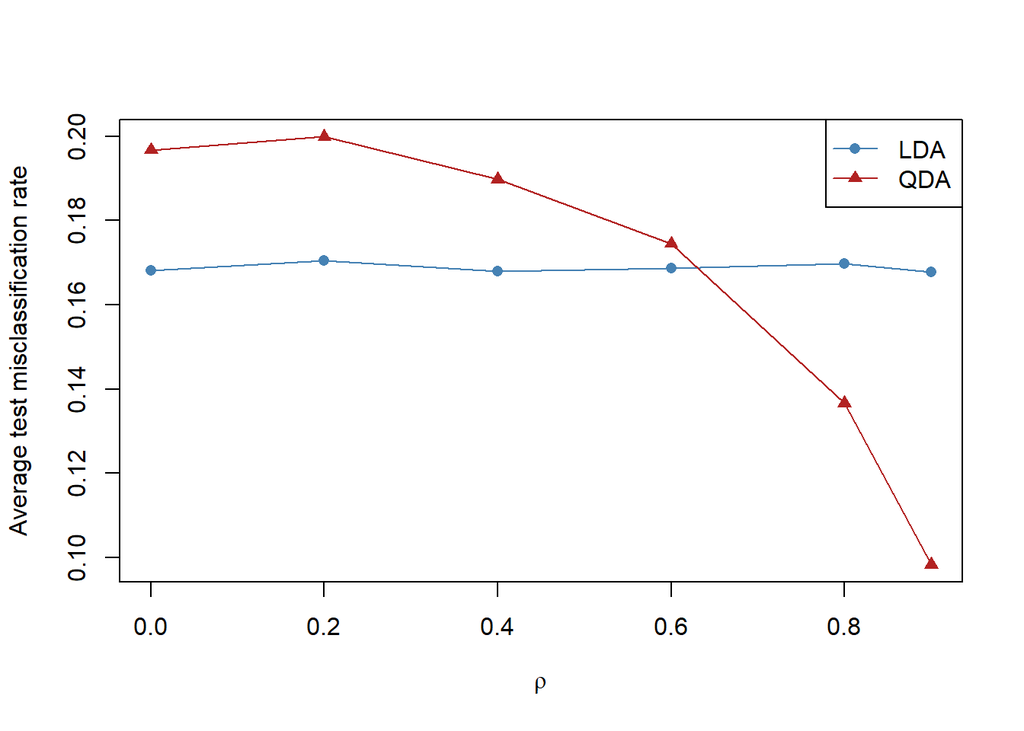

```r
plot(
  rho_values,
  part_b$LDA,
  type = "o",
  pch = 16,
  ylim = range(c(part_b$LDA, part_b$QDA)),
  xlab = expression(rho),
  ylab = "Average test misclassification rate",
  col = "steelblue"
)
lines(
  rho_values,
  part_b$QDA,
  type = "o",
  pch = 17,
  col = "firebrick"
)
legend(
  "topright",
  legend = c("LDA", "QDA"),
  col = c("steelblue", "firebrick"),
  pch = c(16, 17),
  lty = 1
)
```

The average test misclassification rates are:

| $\rho$ | LDA | QDA |
| --- | --- | --- |
| 0.0 | 0.1682 | 0.1968 |
| 0.2 | 0.1706 | 0.1999 |
| 0.4 | 0.1679 | 0.1898 |
| 0.6 | 0.1686 | 0.1745 |
| 0.8 | 0.1698 | 0.1367 |
| 0.9 | 0.1678 | 0.0983 |

### (c)

When $\rho$ is small, the two classes have similar covariance matrices, so the common-covariance assumption of LDA is approximately correct. LDA has lower variance because it estimates one pooled covariance matrix, while QDA estimates a separate covariance matrix for each class. Therefore, LDA performs better at small values of $\rho$.

When $\rho$ is large, the covariance matrices differ substantially between the two classes: the first two variables have opposite correlations. QDA can model this difference, while LDA cannot, so QDA’s lower bias outweighs its higher variance. This is why QDA performs better at large values of $\rho$.

The eight noise covariates have the same distribution in both classes and contain no class information. However, both methods still estimate parameters for them. Their sampling noise increases model variance and can make classification less accurate, especially for QDA because it estimates two full covariance matrices. This is another example of the bias-variance trade-off.

## Question 4: Create and use an LDA/QDA analysis skill

In Homework 5, you created a skill for formatting plots. Now create a reusable skill that guides an AI agent through an LDA/QDA analysis and produces a concise statistical report. You may work with AI to design and write the skill; you do not need to write every line yourself.

1. **Define the skill.** Write a single `SKILL.md` file no larger than **5 KB (5,000 bytes)**. Define the agent’s behavior, analysis guidelines, and expected report structure. Keep the skill independent of this question: provide the dataset, response, and predictors separately when invoking it. The skill may guide the agent to explore lower-dimensional representations, such as principal component analysis (PCA), or to blend the class probabilities predicted by LDA and QDA. Keep all classifiers based on LDA, QDA, or their combination. Configure the skill to load **only when you explicitly invoke it**. Use your AI tool’s invocation settings, or keep the file outside automatically loaded skill folders and supply it only in an explicit request.

Your skill must require a clearly readable analysis report of **at most one printed page**, containing a figure, a table, and numerical model-fitting results. You may specify the type and style of figures and tables you want the AI to produce. All instructions in the skill must be independent of the actual dataset, its variable names, and its observed results. The report should briefly describe the candidate models, the cross-validation procedure and results, the selected model, and its estimated prediction error. It should explain the main findings and any limitations.

2. **Apply the skill.** Explicitly invoke your skill to analyze the `SAheart` data from Question 1, using the same response and predictor coding. Ask the agent to seek the best predictive performance within the LDA/QDA methods allowed by your skill. Include ordinary LDA and QDA as comparisons; the extensions above are optional. Reserve a test set before choosing models. Use the same cross-validation folds within the training data to compare candidates and select any settings. Estimate any preprocessing, including an embedding, using only the training observations in each fold. Refit the selected model and preprocessing on all training observations, then evaluate the fitted classifier once on the reserved test set. Use misclassification rate to compare performance, and report your random seed.
3. **Review and submit.** Check the agent’s analysis and make any skill revisions using only training and cross-validation results. Append the final one-page analysis report and the complete contents of your `SKILL.md` to your homework report. State the file size and briefly explain how you enabled explicit invocation, including the prompt used to apply the skill. The one-page limit applies to the analysis report; the appended skill and this explanation are outside that limit.

Your skill and analysis report will be reviewed and graded by other students through peer evaluation.

## Solution to Question 4

### (a)

I created the standalone `SKILL.md` file. It is 2,753 bytes, below the required 5,000-byte limit. It is outside automatically loaded skill folders, so it is only used when explicitly supplied in a prompt.

### (b)

I applied the skill to `SAheart`, using `chd` as the response and all nine other columns as predictors. I coded `famhist` as a factor and then used the same numerical coding as in Question 1. I reserved 30% of the observations as an independent test set, used five-fold cross-validation on the remaining 70%, and used the same folds for LDA and QDA. The random seed was 432.

```r
library(MASS)

set.seed(432)
heart_q4 <- read.csv("data/saheart.csv")
heart_q4$famhist <- factor(
  heart_q4$famhist,
  levels = c("Absent", "Present")
)
str(heart_q4)
```

```
'data.frame':   462 obs. of  10 variables:
 $ sbp      : int  160 144 118 170 134 132 142 114 114 132 ...
 $ tobacco  : num  12 0.01 0.08 7.5 13.6 6.2 4.05 4.08 0 0 ...
 $ ldl      : num  5.73 4.41 3.48 6.41 3.5 6.47 3.38 4.59 3.83 5.8 ...
 $ adiposity: num  23.1 28.6 32.3 38 27.8 ...
 $ famhist  : Factor w/ 2 levels "Absent","Present": 2 1 2 2 2 2 1 2 2 2 ...
 $ typea    : int  49 55 52 51 60 62 59 62 49 69 ...
 $ obesity  : num  25.3 28.9 29.1 32 26 ...
 $ alcohol  : num  97.2 2.06 3.81 24.26 57.34 ...
 $ age      : int  52 63 46 58 49 45 38 58 29 53 ...
 $ chd      : int  1 1 0 1 1 0 0 1 0 1 ...
```

```r
summary(heart_q4)
```

```
      sbp           tobacco             ldl           adiposity
 Min.   :101.0   Min.   : 0.0000   Min.   : 0.980   Min.   : 6.74
 1st Qu.:124.0   1st Qu.: 0.0525   1st Qu.: 3.283   1st Qu.:19.77
 Median :134.0   Median : 2.0000   Median : 4.340   Median :26.11
 Mean   :138.3   Mean   : 3.6356   Mean   : 4.740   Mean   :25.41
 3rd Qu.:148.0   3rd Qu.: 5.5000   3rd Qu.: 5.790   3rd Qu.:31.23
 Max.   :218.0   Max.   :31.2000   Max.   :15.330   Max.   :42.49
    famhist        typea         obesity         alcohol            age
 Absent :270   Min.   :13.0   Min.   :14.70   Min.   :  0.00   Min.   :15.00
 Present:192   1st Qu.:47.0   1st Qu.:22.98   1st Qu.:  0.51   1st Qu.:31.00
               Median :53.0   Median :25.80   Median :  7.51   Median :45.00
               Mean   :53.1   Mean   :26.04   Mean   : 17.04   Mean   :42.82
               3rd Qu.:60.0   3rd Qu.:28.50   3rd Qu.: 23.89   3rd Qu.:55.00
               Max.   :78.0   Max.   :46.58   Max.   :147.19   Max.   :64.00
      chd
 Min.   :0.0000
 1st Qu.:0.0000
 Median :0.0000
 Mean   :0.3463
 3rd Qu.:1.0000
 Max.   :1.0000
```

```r
colSums(is.na(heart_q4))
```

```
      sbp   tobacco       ldl adiposity   famhist     typea   obesity   alcohol
        0         0         0         0         0         0         0         0
      age       chd
        0         0
```

```r
vapply(heart_q4, function(z) length(unique(z)), integer(1))
```

```
      sbp   tobacco       ldl adiposity   famhist     typea   obesity   alcohol
       62       214       329       408         2        54       400       249
      age       chd
       49         2
```

```r
heart_q4 <- heart_q4[complete.cases(heart_q4), ]

X_q4 <- data.matrix(heart_q4[, names(heart_q4) != "chd"])
y_q4 <- factor(heart_q4$chd, levels = c(0, 1))
train_id_q4 <- sample(
  seq_len(nrow(heart_q4)),
  size = floor(0.70 * nrow(heart_q4))
)
train_x_q4 <- X_q4[train_id_q4, , drop = FALSE]
train_y_q4 <- y_q4[train_id_q4]
test_x_q4 <- X_q4[-train_id_q4, , drop = FALSE]
test_y_q4 <- y_q4[-train_id_q4]
fold_id_q4 <- sample(rep(1:5, length.out = nrow(train_x_q4)))

fit_cv_error_q4 <- function(method) {
  vapply(1:5, function(fold) {
    in_fold <- fold_id_q4 != fold
    out_fold <- !in_fold
    y_fit <- droplevels(train_y_q4[in_fold])
    priors <- as.numeric(prop.table(table(y_fit)))
    names(priors) <- levels(y_fit)
    fit <- if (method == "LDA") {
      lda(train_x_q4[in_fold, , drop = FALSE], y_fit, prior = priors)
    } else {
      qda(train_x_q4[in_fold, , drop = FALSE], y_fit, prior = priors)
    }
    prediction <- predict(
      fit,
      train_x_q4[out_fold, , drop = FALSE]
    )$class
    mean(prediction != train_y_q4[out_fold])
  }, numeric(1))
}

cv_fold_errors_q4 <- rbind(
  LDA = fit_cv_error_q4("LDA"),
  QDA = fit_cv_error_q4("QDA")
)
cv_error_q4 <- rowMeans(cv_fold_errors_q4)
cv_fold_errors_q4
```

```
         [,1]      [,2]      [,3]     [,4]     [,5]
LDA 0.2615385 0.2615385 0.3076923 0.296875 0.187500
QDA 0.2461538 0.3384615 0.2923077 0.296875 0.265625
```

```r
cv_error_q4
```

```
      LDA       QDA
0.2630288 0.2878846
```

```r
selected_q4 <- names(which.min(cv_error_q4))
final_priors_q4 <- as.numeric(prop.table(table(train_y_q4)))
names(final_priors_q4) <- levels(train_y_q4)
final_priors_q4
```

```
        0         1
0.6563467 0.3436533
```

```r
table(train_y_q4)
```

```
train_y_q4
  0   1
212 111
```

```r
final_fit_q4 <- if (selected_q4 == "LDA") {
  lda(train_x_q4, train_y_q4, prior = final_priors_q4)
} else {
  qda(train_x_q4, train_y_q4, prior = final_priors_q4)
}

test_prediction_q4 <- predict(final_fit_q4, test_x_q4)$class
test_confusion_q4 <- table(
  Observed = test_y_q4,
  Predicted = factor(
    test_prediction_q4,
    levels = levels(test_y_q4)
  )
)
test_confusion_q4
```

```
        Predicted
Observed  0  1
       0 75 15
       1 23 26
```

```r
test_error_q4 <- mean(test_prediction_q4 != test_y_q4)
test_error_q4
```

```
[1] 0.2733813
```

```r
test_class_error_q4 <- tapply(
  test_prediction_q4 != test_y_q4,
  test_y_q4,
  mean
)
test_class_error_q4
```

```
        0         1
0.1666667 0.4693878
```

#### Compact one-page analysis report

The `SAheart` data contain 462 complete observations, with `chd` as the response and nine predictors. I coded `famhist` as Absent = 1 and Present = 2, reserved 30% of the observations for testing, and used five-fold cross-validation on the remaining training data. The random seed was 432, and the same folds were used for both models.

The training set contains 323 observations and the independent test set contains 139 observations. The training class proportions (used as empirical priors) are 0.6563 for `chd = 0` and 0.3437 for `chd = 1`.

| Model | Fold 1 | Fold 2 | Fold 3 | Fold 4 | Fold 5 | Mean CV error |
| --- | --- | --- | --- | --- | --- | --- |
| LDA | 0.2615 | 0.2615 | 0.3077 | 0.2969 | 0.1875 | 0.2630 |
| QDA | 0.2462 | 0.3385 | 0.2923 | 0.2969 | 0.2656 | 0.2879 |

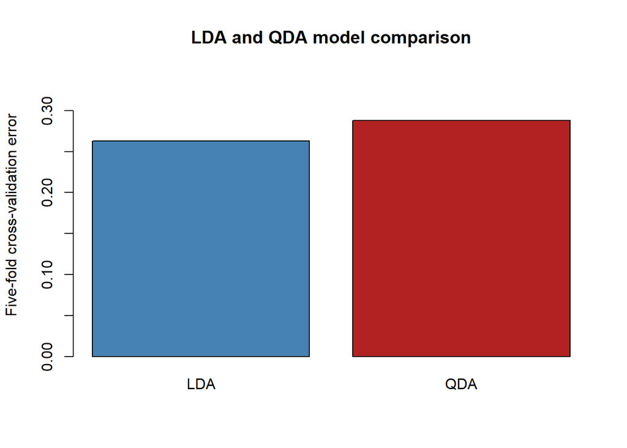

LDA was selected because it had the lower cross-validation error. On the untouched test set, its confusion matrix was:

| Observed / Predicted | 0 | 1 |
| --- | --- | --- |
| 0 | 75 | 15 |
| 1 | 23 | 26 |

The final test misclassification rate was 0.2734. The class-specific test error rates were 0.1667 for class 0 and 0.4694 for class 1. The independent test error is close to the cross-validation error for the selected LDA model. LDA’s equal-covariance assumption is a limitation; QDA has more variance because it estimates separate covariance matrices. Class imbalance and the numeric encoding of `famhist` may also affect performance.

#### Supporting R code and outputs

The data had 462 complete observations: 323 training observations and 139 test observations. The five-fold cross-validation results were:

| Model | Mean CV error |
| --- | --- |
| LDA | 0.2630 |
| QDA | 0.2879 |

LDA was selected. Its held-out test confusion matrix was:

| Observed / Predicted | 0 | 1 |
| --- | --- | --- |
| 0 | 75 | 15 |
| 1 | 23 | 26 |

The final test misclassification rate was $0.2734$, or $27.34\%$.

### (c)

The cross-validation results support LDA for this split because its pooled covariance estimate performed better than QDA’s separate covariance estimates. The independent test error is close to the cross-validation error for the selected LDA model. LDA assumes approximately equal class covariance matrices; QDA allows different covariance matrices but has greater estimation variance. The normality and covariance assumptions are only approximate, and class imbalance and the categorical-to-numeric conversion of `famhist` are limitations.

The explicit invocation prompt was:

> Explicitly invoke the `SKILL.md` LDA/QDA analysis skill. Analyze `data/saheart.csv` using `chd` as the response and all other variables as predictors, with `famhist` coded as Absent = 1 and Present = 2. Reserve a test set before model selection, compare ordinary LDA and QDA using the same five-fold cross-validation folds, select by misclassification rate, and report the final test confusion matrix, error, assumptions, limitations, seed, table, and figure.

The complete contents of `SKILL.md` are:

[output not shown]